# Project 7 - Unsupervised Learning Techniques

## Unsupervised Learning - Clustering - AllLife Bank Customer Segmentation Case Study

### Background and Context

AllLife Bank wants to focus on its credit card customer base in the next financial year. They have been advised by their marketing research team, that the penetration in the market can be improved. Based on this input, the Marketing team proposes to run personalized campaigns to target new customers as well as upsell to existing customers. Another insight from the market research was that the customers perceive the support services of the back poorly. Based on this, the Operations team wants to upgrade the service delivery model, to ensure that customer queries are resolved faster. Head of Marketing and Head of Delivery both decide to reach out to the Data Science team for help

### Objective

To identify different segments in the existing customer, based on their spending patterns as well as past interaction with the bank, using clustering algorithms, and provide recommendations to the bank on how to better market to and service these customers.

### Data Description

The data provided is of various customers of a bank and their financial attributes like credit limit, the total number of credit cards the customer has, and different channels through which customers have contacted the bank for any queries (including visiting the bank, online and through a call center).

### Data Dictionary

- Sl_No: Primary key of the records
- Customer Key: Customer identification number
- Average Credit Limit: Average credit limit of each customer for all credit cards
- Total credit cards: Total number of credit cards possessed by the customer
- Total visits bank: Total number of Visits that customer made (yearly) personally to the bank
- Total visits online: Total number of visits or online logins made by the customer (yearly)
- Total calls made: Total number of calls made by the customer to the bank or its customer service department (yearly)

### Import libraries

```python
import warnings
warnings.filterwarnings("ignore")

# Libraries to help with reading and manipulating data
import numpy as np
import pandas as pd

# Libraries to help with data visualization
import matplotlib.pyplot as plt
import seaborn as sns

# to scale the data using z-score
from sklearn.preprocessing import StandardScaler

# to compute distances
from scipy.spatial.distance import cdist

# to perform k-means clustering and compute silhouette scores
from sklearn.cluster import KMeans
from sklearn.metrics import silhouette_score

# to visualize the elbow curve and silhouette scores
from yellowbrick.cluster import KElbowVisualizer, SilhouetteVisualizer

# to compute distances
from scipy.spatial.distance import pdist

# to perform hierarchical clustering, compute cophenetic correlation, and create dendrograms
from sklearn.cluster import AgglomerativeClustering
from scipy.cluster.hierarchy import dendrogram, linkage, cophenet

# to perform PCA
from sklearn.decomposition import PCA
```

### Loading Dataset

```python
# loading the dataset
data = pd.read_excel('Credit Card Customer Data.xlsx', sheet_name = 'Sheet1')

# Make a copy of dataset
customer_data = data.copy()
```

### View the first and last 5 rows of the dataset

```python
#Print the first five rows of the dataset
print(customer_data.head())

#Print the last five rows of the dataset
print(customer_data.tail())
```

```
   Sl_No  Customer Key  Avg_Credit_Limit  Total_Credit_Cards  \
0      1         87073            100000                   2
1      2         38414             50000                   3
2      3         17341             50000                   7
3      4         40496             30000                   5
4      5         47437            100000                   6

   Total_visits_bank  Total_visits_online  Total_calls_made
0                  1                    1                 0
1                  0                   10                 9
2                  1                    3                 4
3                  1                    1                 4
4                  0                   12                 3
     Sl_No  Customer Key  Avg_Credit_Limit  Total_Credit_Cards  \
655    656         51108             99000                  10
656    657         60732             84000                  10
657    658         53834            145000                   8
658    659         80655            172000                  10
659    660         80150            167000                   9

     Total_visits_bank  Total_visits_online  Total_calls_made
655                  1                   10                 0
656                  1                   13                 2
657                  1                    9                 1
658                  1                   15                 0
659                  0                   12                 2
```

### Understand the shape of the dataset

```python
data.shape
```

```
(660, 7)
```

#### Observations:

- This dataset has 660 rows and 7 columns.

### Let us check for null values and duplicates

```python
#Check for null values and duplicates
print (customer_data.isna().sum())
print(customer_data.duplicated().sum())
```

```
Sl_No                  0
Customer Key           0
Avg_Credit_Limit       0
Total_Credit_Cards     0
Total_visits_bank      0
Total_visits_online    0
Total_calls_made       0
dtype: int64
0
```

#### Observations:

- **There are no missing values in the data.**
- **There are no duplicate values in the data.**

### Check the data types of the columns for the dataset

```python
#Check the column datatypes
print(customer_data.info())
```

```
<class 'pandas.core.frame.DataFrame'>
RangeIndex: 660 entries, 0 to 659
Data columns (total 7 columns):
 #   Column               Non-Null Count  Dtype
---  ------               --------------  -----
 0   Sl_No                660 non-null    int64
 1   Customer Key         660 non-null    int64
 2   Avg_Credit_Limit     660 non-null    int64
 3   Total_Credit_Cards   660 non-null    int64
 4   Total_visits_bank    660 non-null    int64
 5   Total_visits_online  660 non-null    int64
 6   Total_calls_made     660 non-null    int64
dtypes: int64(7)
memory usage: 36.2 KB
None
```

#### Observations:

- All the variables are of int datatype.
- No conversion needed.

### Summary of the dataset

```python
#Check the summary of dataset
print(customer_data.describe())
```

```
            Sl_No  Customer Key  Avg_Credit_Limit  Total_Credit_Cards  \
count  660.000000    660.000000        660.000000          660.000000
mean   330.500000  55141.443939      34574.242424            4.706061
std    190.669872  25627.772200      37625.487804            2.167835
min      1.000000  11265.000000       3000.000000            1.000000
25%    165.750000  33825.250000      10000.000000            3.000000
50%    330.500000  53874.500000      18000.000000            5.000000
75%    495.250000  77202.500000      48000.000000            6.000000
max    660.000000  99843.000000     200000.000000           10.000000

       Total_visits_bank  Total_visits_online  Total_calls_made
count         660.000000           660.000000        660.000000
mean            2.403030             2.606061          3.583333
std             1.631813             2.935724          2.865317
min             0.000000             0.000000          0.000000
25%             1.000000             1.000000          1.000000
50%             2.000000             2.000000          3.000000
75%             4.000000             4.000000          5.000000
max             5.000000            15.000000         10.000000
```

#### Observations:

- **Sl.No** and **Customer key** are unique ids and is of no significant statistical importance and will be dropped for analysis and clustering.
- **Avg_Credit_Limit:** Around 50% of the data has a credit limt of 18K and the huge difference between the 75%(48k) and maximum(200k) indicates presence of outliers in this variable.This has drifted the mean to 34k compared to the median value of 18k.
- **Total_Credit_Cards:** The average number of credit cards a customer has is around 4 and around 50% of the customers in this dataset have 5 cards.
- **Total_visits_bank:** The average number of times a customer has visited the bank is 2 and this is same as the median value around 50% of the customers have also visited the nbank twice for some queries.
- **Total_visits_online:** The average number of times a customer had made online visits is 2 and this is same as the median value.The steep difference between the 75% and max value indicates the presence of upper outliers in the data.
- **Total_calls_made:** The average number of calls made by a customer to the bank is 3 and this is in line with the 50% of customers as well.The difference in 75% and max value gives us a hint to check for outliers in this variable.

### Data Preprocessing - Renaming Customer Key column to Customer_Key for analysis

```python
# Data Preprocessing - Renaming 'Customer Key' column to 'Customer_Key'
customer_data = customer_data.rename(columns = {'Customer Key':'Customer_Key'})
```

#### Observations:

- Customer Key column has been renamed to Customer_Key.

### Lets us look at different columns for Unique Data count

```python
# Assigning the dataframe columns to a variable
num_columns = customer_data.describe(include = 'all').columns
num_columns
```

```
Index(['Sl_No', 'Customer_Key', 'Avg_Credit_Limit', 'Total_Credit_Cards',
       'Total_visits_bank', 'Total_visits_online', 'Total_calls_made'],
      dtype='object')
```

```python
for i in num_columns:
    print('Unique values in',i, 'are :')
    print(customer_data[i].value_counts())
    print('*'*50)
```

```
Unique values in Sl_No are :
660    1
226    1
224    1
223    1
222    1
      ..
440    1
439    1
438    1
437    1
1      1
Name: Sl_No, Length: 660, dtype: int64
Unique values in Customer_Key are :
47437    2
```

[output cut: 75 more lines]

#### Observations:

- There are no negative values in any of the columns.
- There are no missing or special values in any of the columns.
- In the Customer Key column we could see 5 ids being repeated two times each which we will investigae further for duplicate evaluation.

### Let us check the double occurence of the 5 customer ids to check for data duplication.

```python
 print(customer_data[customer_data.Customer_Key == 47437])
 print(customer_data[customer_data.Customer_Key == 37252])
 print(customer_data[customer_data.Customer_Key == 97935])
 print(customer_data[customer_data.Customer_Key == 96929])
 print(customer_data[customer_data.Customer_Key == 50706])
```

```
     Sl_No  Customer_Key  Avg_Credit_Limit  Total_Credit_Cards  \
4        5         47437            100000                   6
332    333         47437             17000                   7

     Total_visits_bank  Total_visits_online  Total_calls_made
4                    0                   12                 3
332                  3                    1                 0
     Sl_No  Customer_Key  Avg_Credit_Limit  Total_Credit_Cards  \
48      49         37252              6000                   4
432    433         37252             59000                   6

     Total_visits_bank  Total_visits_online  Total_calls_made
48                   0                    2                 8
432                  2                    1                 2
     Sl_No  Customer_Key  Avg_Credit_Limit  Total_Credit_Cards  \
104    105         97935             17000                   2
632    633         97935            187000                   7

     Total_visits_bank  Total_visits_online  Total_calls_made
104                  1                    2                10
632                  1                    7                 0
     Sl_No  Customer_Key  Avg_Credit_Limit  Total_Credit_Cards  \
391    392         96929             13000                   4
398    399         96929             67000                   6

     Total_visits_bank  Total_visits_online  Total_calls_made
391                  5                    0                 0
398                  2                    2                 2
     Sl_No  Customer_Key  Avg_Credit_Limit  Total_Credit_Cards  \
411    412         50706             44000                   4
541    542         50706             60000                   7

     Total_visits_bank  Total_visits_online  Total_calls_made
411                  5                    0                 2
541                  5                    2                 2
```

#### Observations:

- The customer keys **47437,37252,97935,96929,50706** have two rows of data.However not all the other column values are the same hence they cannot be considered as duplicates and this might be due to different customer profiling at various point of time for that customer.

### Data Preprocessing - Feature Engineering

#### Dropping off the Serial no and Client id column from the dataframe

```python
# Client_id is unique for each customer and might not add value to modeling
customer_data.drop(["Sl_No"], axis=1, inplace=True)
customer_data.drop(["Customer_Key"], axis=1, inplace=True)
```

```python
customer_data.head()
```

|  | Avg_Credit_Limit | Total_Credit_Cards | Total_visits_bank | Total_visits_online | Total_calls_made |
| --- | --- | --- | --- | --- | --- |
| 0 | 100000 | 2 | 1 | 1 | 0 |
| 1 | 50000 | 3 | 0 | 10 | 9 |
| 2 | 50000 | 7 | 1 | 3 | 4 |
| 3 | 30000 | 5 | 1 | 1 | 4 |
| 4 | 100000 | 6 | 0 | 12 | 3 |

### EDA - Exploratory Data Analysis

### Univariate Analysis

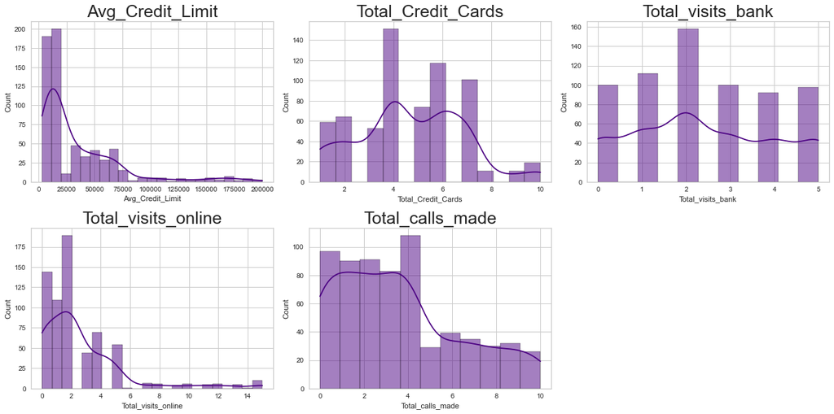

```python
# lets plot histogram of all numerical variables
all_col = customer_data.select_dtypes(include=np.number).columns.tolist()
plt.figure(figsize=(17, 75))

for i in range(len(all_col)):
    plt.subplot(18, 3, i + 1)
    sns.histplot(customer_data[all_col[i]], kde=True, color="indigo")
    plt.tight_layout()
    plt.title(all_col[i], fontsize=25)

plt.show()
```

#### Observations:

**Avg_credit_limit:** The average credit limit is heavily right skewed indicating presence of outliers on the higher end on the data.

**Total_Credit_Cards:** We can see a kind of bimodal distribution in data with two peaks and not many outliers.

**Total_visits_bank:** This is kind of normally distributed with no outliers.

**Total_visits_online:** This variable is righted skewed and indicates presence of outliers.The average peak here is around 2.

**Total_calls_made:** This distribution tells us around 50% of the customers has made around 3 to 4 calls and the remaining over 5 times.The average peak is around 3.

#### Let's write a function to plot the histogram and boxplot together for numeric variables

```python
# While doing uni-variate analysis of numerical variables we want to study their central tendency
# and dispersion.
# Let us write a function that will help us create boxplot and histogram for any input numerical
# variable.
# This function takes the numerical column as the input and returns the boxplots
# and histograms for the variable.
def histogram_boxplot(feature, figsize=(10,5), bins = None):
    """ Boxplot and histogram combined
    feature: 1-d feature array
    figsize: size of fig (default (9,8))
    bins: number of bins (default None / auto)
    """
    f2, (ax_box2, ax_hist2) = plt.subplots(nrows = 2, # Number of rows of the subplot grid= 2
                                           sharex = True, # x-axis will be shared among all subplots
                                           gridspec_kw = {"height_ratios": (.25, .75)},
                                           figsize = figsize
                                           ) # creating the 2 subplots
    sns.boxplot(feature, ax=ax_box2, showmeans=True, color='yellow') # boxplot will be created and a star will indicate the mean value of the column
    sns.histplot(feature, kde=F, ax=ax_hist2, bins=bins,color = 'cyan') if bins else sns.histplot(feature, kde=True, ax=ax_hist2,color='blue') # For histogram
    ax_hist2.axvline(np.mean(feature), color='red', linestyle='--') # Add mean to the histogram
    ax_hist2.axvline(np.median(feature), color='black', linestyle='-') # Add median to the histogram
```

### Observations on Avg_Credit_Limit

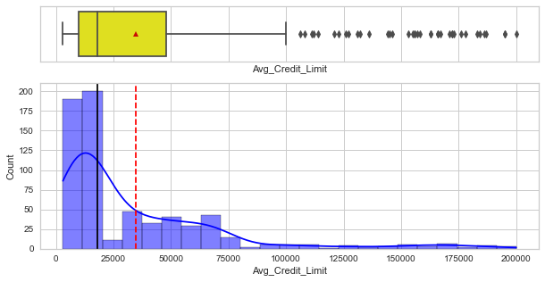

```python
histogram_boxplot(customer_data.Avg_Credit_Limit)
```

### Observations on Total_Credit_Cards

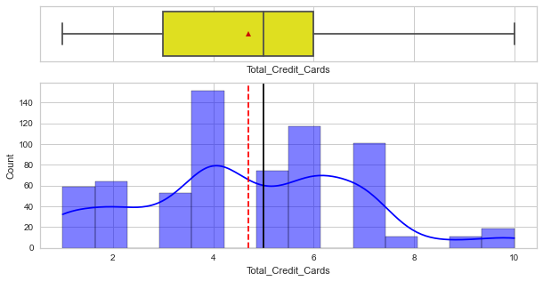

```python
histogram_boxplot(customer_data.Total_Credit_Cards)
```

#### Observations:

- The average number of credit cards that the customers have is around 5.
- The mean and the median are almost equal with no outliers.

### Observations on Total_visits_bank

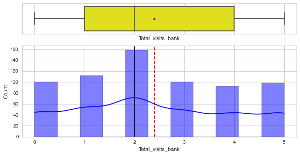

```python
histogram_boxplot(customer_data.Total_visits_bank)
```

#### Observations:

- The average number of visits that customers make to the bank is around 2.
- The mean and the median are very close with no outliers.

### Observations on Total_visits_online

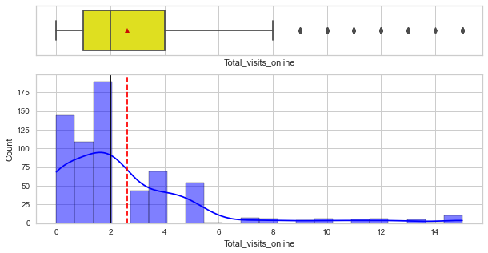

```python
histogram_boxplot(customer_data.Total_visits_online)
```

#### Observations:

- The average number of visits that customers make online is around 3.
- There are many upper/higher end outliers in the data and the distribution is right skewed.

### Observations on Total_calls_made

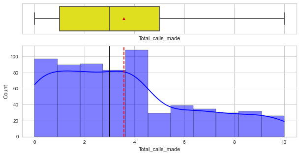

```python
histogram_boxplot(customer_data.Total_calls_made)
```

#### Observations:

- Around 50% of the customers have made around 3 calls to the bank.
- The mean and median are also very close and there are not many outlier in this variable.

#### Let's write a function to calculate the percentage for the countplot

```python
# Function to create barplots that indicate percentage for each category.

def perc_on_bar(z):
    '''
    plot
    feature: categorical feature
    the function won't work if a column is passed in hue parameter
    '''
    total = len(customer_data[z]) # length of the column
    plt.figure(figsize=(15,5))
    #plt.xticks(rotation=45)
    ax = sns.countplot(customer_data[z],palette='Paired')
    for p in ax.patches:
        percentage = '{:.1f}%'.format(100 * p.get_height()/total) # percentage of each class of the category
       # x = p.get_x() + p.get_width() / 2 - 0.05 # width of the plot
       # y = p.get_y() + p.get_height()           # hieght of the plot
        x = p.get_x() + p.get_width() / total + 0.2  # width of the plot
        y = p.get_y() + p.get_height()  # height of the plot
        ax.annotate(percentage,(x, y), size = 10) # annotate the percantage
    plt.xticks(rotation = 90)
    plt.show() # show the plot
```

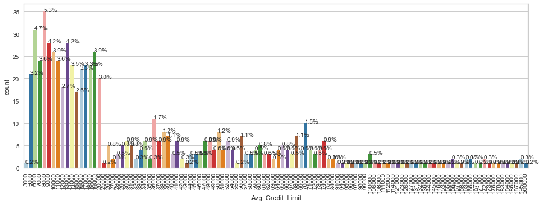

```python
perc_on_bar('Avg_Credit_Limit')
```

#### Observations:

- Around 50% of the data is below 20k.
- 5.3% of customers have a credit limit of 8k being the highest concentration followed by 4.7% of customer with credit limit of 6k.

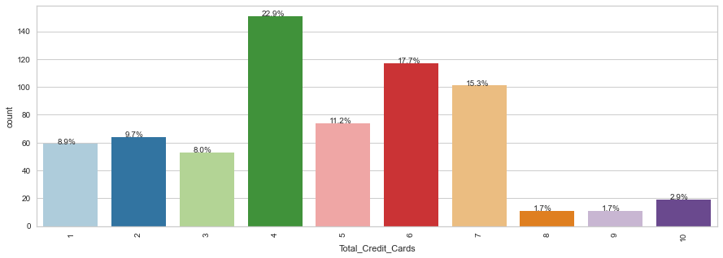

```python
perc_on_bar('Total_Credit_Cards')
```

#### Observations:

- Around 23% of the customers have 4 credit cards in average topping the list followed by customers who have 6 cards at around 18%.

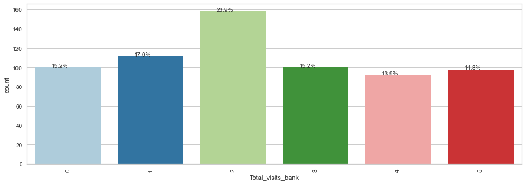

```python
perc_on_bar('Total_visits_bank')
```

#### Observations:

- Around 24% of the customers have made 2 visits to the bank being the highest in the list followed by 1 visit which is around 17%.

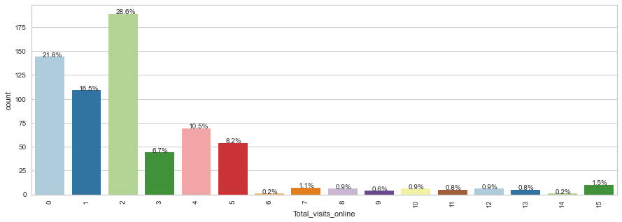

```python
perc_on_bar('Total_visits_online')
```

#### Observations:

- Around 29% of the customers have made 2 online visits to the bank that being the top followed by 22% who have made no online visits.
- This data gives a clear insight that not a lot of customers are using the online banking facility that much.

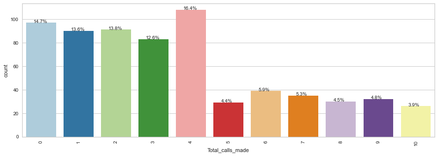

```python
perc_on_bar('Total_calls_made')
```

#### Observations:

- Around 17% of the customers have made 4 calls to the bank that being the top followed by 15% who have made no calls.

### Bivariate Analysis

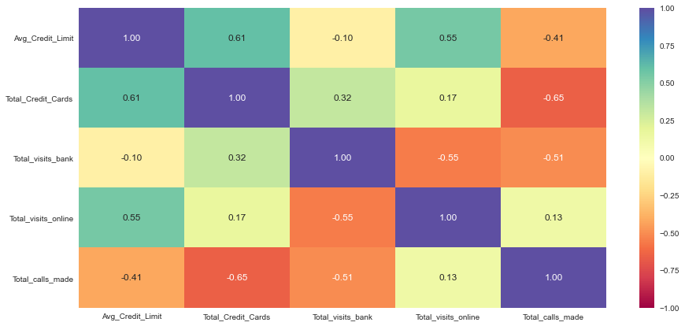

```python
plt.figure(figsize=(15, 7))
sns.heatmap(customer_data.corr(), annot=True, vmin=-1, vmax=1, fmt=".2f", cmap="Spectral")
plt.show()
```

#### Observations:

- We cannot see any strong correlations here.
- The top positive correlation we can see is between Total_Credit_cards and Avg_Credit_Limit is 0.61, the more number of cards the higher the credit limit.
- The top negative correlation is between Total_Credit_cards and Total_call_made is -0.65, the more number of cards a customer has the lesser calls he has made to the bank.(happy customers)and the lesser number of cards, the more calls made to the bank(unhappy customers).

```python
customer_data.corr()
```

|  | Avg_Credit_Limit | Total_Credit_Cards | Total_visits_bank | Total_visits_online | Total_calls_made |
| --- | --- | --- | --- | --- | --- |
| Avg_Credit_Limit | 1.000000 | 0.608860 | -0.100312 | 0.551385 | -0.414352 |
| Total_Credit_Cards | 0.608860 | 1.000000 | 0.315796 | 0.167758 | -0.651251 |
| Total_visits_bank | -0.100312 | 0.315796 | 1.000000 | -0.551861 | -0.506016 |
| Total_visits_online | 0.551385 | 0.167758 | -0.551861 | 1.000000 | 0.127299 |
| Total_calls_made | -0.414352 | -0.651251 | -0.506016 | 0.127299 | 1.000000 |

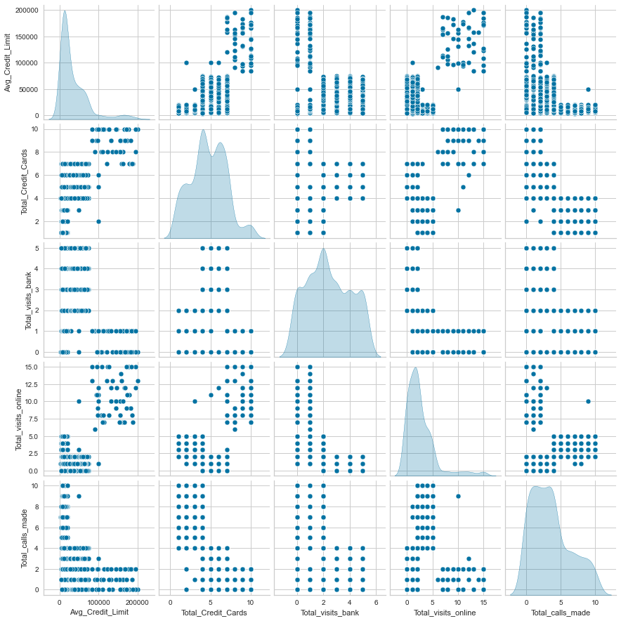

```python
sns.pairplot(data=customer_data, diag_kind="kde")
plt.show()
```

#### Observations:

- We can see varying distributions for different variables, we should investigate it further.

### Outlier Detection

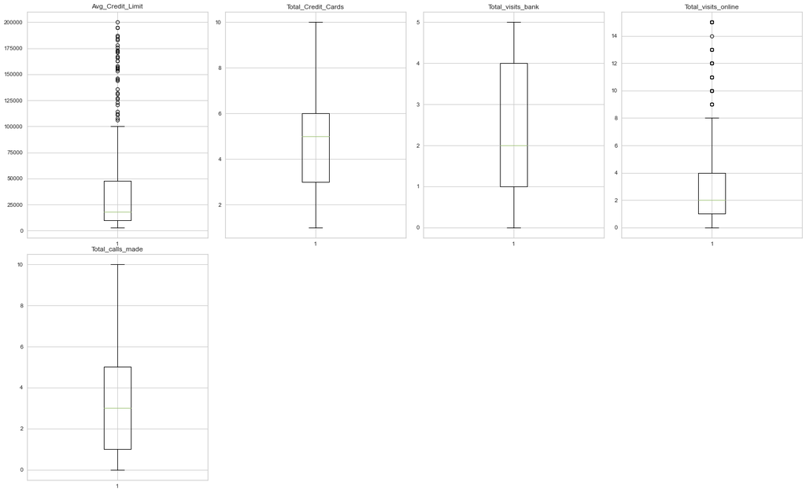

```python
numerical_col = customer_data.select_dtypes(include=np.number).columns.tolist()
plt.figure(figsize=(20,30))

for i, variable in enumerate(numerical_col):
                     plt.subplot(5,4,i+1)
                     plt.boxplot(customer_data[variable],whis=1.5)
                     plt.tight_layout()
                     plt.title(variable)

plt.show()
```

#### Observations:

- We can see that two of the variables Avg_Credit_Limit and Total_visits_online has upper outliers.
- We will cap them for our model.

### Outlier Treatment

```python
def treat_outliers(data,col):
    '''
    treats outliers in a varaible
    col: str, name of the numerical varaible
    data: data frame
    col: name of the column
    '''
    Q1=data[col].quantile(0.25) # 25th quantile
    Q3=data[col].quantile(0.75)  # 75th quantile
    IQR=Q3-Q1
    Lower_Whisker = Q1 - 1.5*IQR
    Upper_Whisker = Q3 + 1.5*IQR
    data[col] = np.clip(data[col], Lower_Whisker, Upper_Whisker) # all the values smaller than Lower_Whisker will be assigned value of Lower_whisker
                                                            # and all the values above upper_whisker will be assigned value of upper_Whisker
    return data

def treat_outliers_all(data, col_list):
    '''
    treat outlier in all numerical varaibles
    col_list: list of numerical varaibles
    data: data frame
    '''
    for c in col_list:
        data = treat_outliers(data,c)

    return data

numerical_col = customer_data.select_dtypes(include=np.number).columns.tolist()# getting list of numerical columns
customer_data = treat_outliers_all(customer_data,numerical_col)
```

### Lets check the Outlier Treatment

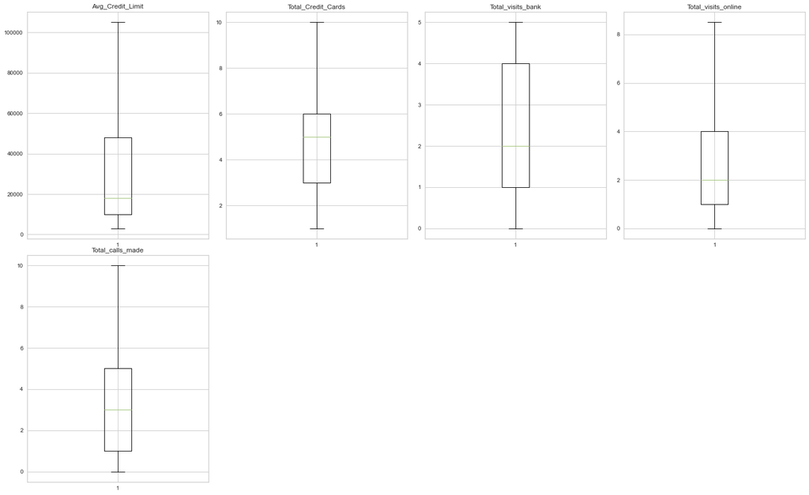

```python
numerical_col = customer_data.select_dtypes(include=np.number).columns.tolist()
plt.figure(figsize=(20,30))

for i, variable in enumerate(numerical_col):
                     plt.subplot(5,4,i+1)
                     plt.boxplot(customer_data[variable],whis=1.5)
                     plt.tight_layout()
                     plt.title(variable)

plt.show()
```

#### Observations:

- All the outliers have been capped under the upper and lower whiskers.

### Data Scaling

```python
# Scaling the data set before clustering
scaler = StandardScaler()
customer_data1 = customer_data[numerical_col].copy()
customer_data1_scaled = scaler.fit_transform(customer_data1)
```

```python
# Creating a dataframe from the scaled data
customer_data_scaled_df = pd.DataFrame(customer_data1_scaled, columns=customer_data1.columns)
```

### K Means Clustering

```
Number of Clusters: 1 	Average Distortion: 2.0731463576129583
Number of Clusters: 2 	Average Distortion: 1.4986141501796377
Number of Clusters: 3 	Average Distortion: 1.1823298853410935
Number of Clusters: 4 	Average Distortion: 1.0711026440504199
Number of Clusters: 5 	Average Distortion: 1.0048733481248666
Number of Clusters: 6 	Average Distortion: 0.9521247989886392
Number of Clusters: 7 	Average Distortion: 0.9148551519758337
Number of Clusters: 8 	Average Distortion: 0.8903452720527884
```

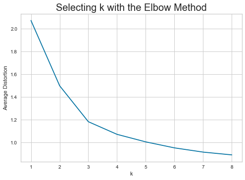

```python
clusters = range(1, 9)
meanDistortions = []

for k in clusters:
    model = KMeans(n_clusters=k)
    model.fit(customer_data_scaled_df)
    prediction = model.predict(customer_data_scaled_df)
    distortion = (
        sum(
            np.min(cdist(customer_data_scaled_df, model.cluster_centers_, "euclidean"), axis=1)
        )
        / customer_data_scaled_df.shape[0]
    )

    meanDistortions.append(distortion)

    print("Number of Clusters:", k, "\tAverage Distortion:", distortion)

plt.plot(clusters, meanDistortions, "bx-")
plt.xlabel("k")
plt.ylabel("Average Distortion")
plt.title("Selecting k with the Elbow Method", fontsize=20)
```

#### The appropriate value of k from the elbow curve seems to be 3 or 4.

#### Let's check the silhouette scores.

```
For n_clusters = 2, silhouette score is 0.4201583924929177
For n_clusters = 3, silhouette score is 0.5169867470092899
For n_clusters = 4, silhouette score is 0.38147048130671246
For n_clusters = 5, silhouette score is 0.35332888701008774
For n_clusters = 6, silhouette score is 0.2710787553380172
For n_clusters = 7, silhouette score is 0.2670715192268191
For n_clusters = 8, silhouette score is 0.2549245436197366
For n_clusters = 9, silhouette score is 0.2500866475137952
```

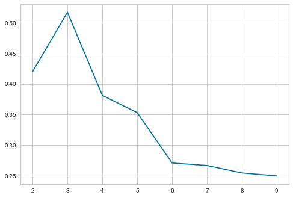

```python
sil_score = []
cluster_list = list(range(2, 10))
for n_clusters in cluster_list:
    clusterer = KMeans(n_clusters=n_clusters)
    preds = clusterer.fit_predict((customer_data_scaled_df))
    # centers = clusterer.cluster_centers_
    score = silhouette_score(customer_data_scaled_df, preds)
    sil_score.append(score)
    print("For n_clusters = {}, silhouette score is {}".format(n_clusters, score))

plt.plot(cluster_list, sil_score)
```

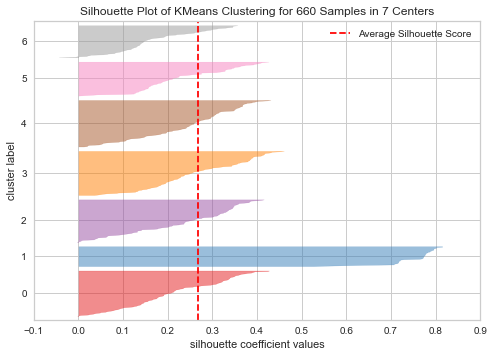

```python
# finding optimal no. of clusters with silhouette coefficients
visualizer = SilhouetteVisualizer(KMeans(7, random_state=1))
visualizer.fit(customer_data_scaled_df)
visualizer.show()
```

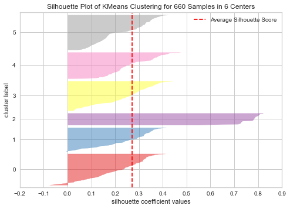

```python
# finding optimal no. of clusters with silhouette coefficients
visualizer = SilhouetteVisualizer(KMeans(6, random_state=1))
visualizer.fit(customer_data_scaled_df)
visualizer.show()
```

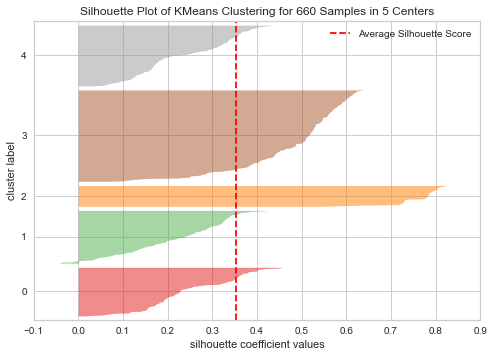

```python
# finding optimal no. of clusters with silhouette coefficients
visualizer = SilhouetteVisualizer(KMeans(5, random_state=1))
visualizer.fit(customer_data_scaled_df)
visualizer.show()
```

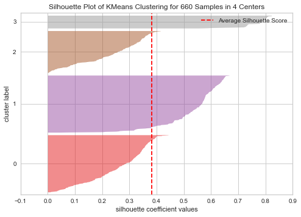

```python
# finding optimal no. of clusters with silhouette coefficients
visualizer = SilhouetteVisualizer(KMeans(4, random_state=1))
visualizer.fit(customer_data_scaled_df)
visualizer.show()
```

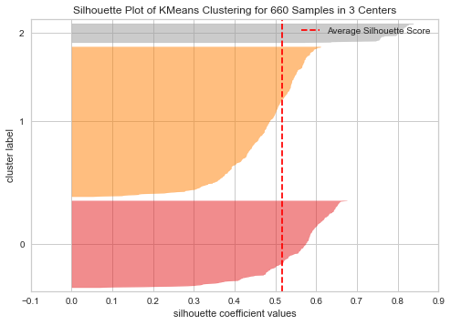

```python
# finding optimal no. of clusters with silhouette coefficients
visualizer = SilhouetteVisualizer(KMeans(3, random_state=1))
visualizer.fit(customer_data_scaled_df)
visualizer.show()
```

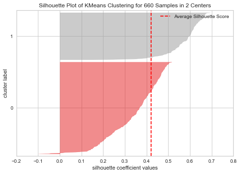

```python
# finding optimal no. of clusters with silhouette coefficients
visualizer = SilhouetteVisualizer(KMeans(2, random_state=1))
visualizer.fit(customer_data_scaled_df)
visualizer.show()
```

#### Let's take 3 as the appropriate no. of clusters as the silhouette score is maximum and there is knick at 3 in the elbow curve complementing each other.

```python
kmeans = KMeans(n_clusters=3, random_state=0)
kmeans.fit(customer_data_scaled_df)
```

```
KMeans(n_clusters=3, random_state=0)
```

```python
# adding kmeans cluster labels to the original dataframe and scaled dataframe
customer_data["K_means_segments"] = kmeans.labels_
customer_data_scaled_df["K_means_segments"] = kmeans.labels_
```

### K Means Cluster Profiling

```python
cluster_profile_kmeans = customer_data.groupby("K_means_segments").mean()
cluster_profile_kmeans_scaled = customer_data_scaled_df.groupby("K_means_segments").mean()
```

```python
cluster_profile_kmeans["count_in_each_segment"] = (
    customer_data.groupby("K_means_segments")["Total_Credit_Cards"].count().values
)
cluster_profile_kmeans_scaled["count_in_each_segment"] = (
    customer_data_scaled_df.groupby("K_means_segments")["Total_Credit_Cards"].count().values
)
```

```python
# let's display cluster profiles
cluster_profile_kmeans.style.highlight_max(color="lightgreen", axis=0)
```

| K_means_segments | Avg_Credit_Limit | Total_Credit_Cards | Total_visits_bank | Total_visits_online | Total_calls_made | count_in_each_segment |
| --- | --- | --- | --- | --- | --- | --- |
| 0 | 33782.383420 | 5.515544 | 3.489637 | 0.981865 | 2.000000 | 386 |
| 1 | 12174.107143 | 2.410714 | 0.933036 | 3.546875 | 6.870536 | 224 |
| 2 | 102660.000000 | 8.740000 | 0.600000 | 8.180000 | 1.080000 | 50 |

```python
cluster_profile_kmeans_scaled.style.highlight_max(color="lightgreen", axis=0)
```

| K_means_segments | Avg_Credit_Limit | Total_Credit_Cards | Total_visits_bank | Total_visits_online | Total_calls_made | count_in_each_segment |
| --- | --- | --- | --- | --- | --- | --- |
| 0 | 0.074275 | 0.373690 | 0.666395 | -0.627808 | -0.553005 | 386 |
| 1 | -0.684315 | -1.059623 | -0.901518 | 0.509544 | 1.148109 | 224 |
| 2 | 2.492325 | 1.862226 | -1.105763 | 2.563922 | -0.874330 | 50 |

### Boxplot and barplot visualization of KMeans Clusters

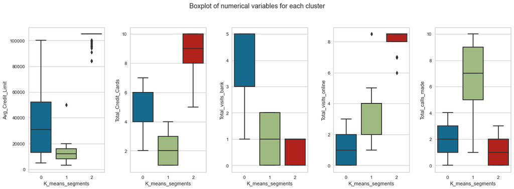

```python
fig, axes = plt.subplots(1, 5, figsize=(16, 6))
fig.suptitle("Boxplot of numerical variables for each cluster")
counter = 0
for ii in range(5):
    sns.boxplot(ax=axes[ii], y=customer_data[numerical_col[counter]], x=customer_data["K_means_segments"])
    counter = counter + 1

fig.tight_layout(pad=2.0)
```

#### Observations:

##### Cluster 2:

- The average credit limit is below 110k.This seems to be the group capturing all the outliers.
- More than 25% of customers in this category have around 8-10 credit cards and the minimum here is 5 maximum is around 10.
- Customers in this cluster group do a minimum number of bank visits 0 or 1.They are mostly online customers.
- Customers in this group have maximum online usage.Most customers has a minimum of 8 online visits to 9 online being the maximum.
- Customers in this cluster group has made least number of calls to the bank on average with a 25% making no calls and maximum of 3 calls.

```python
customer_data_split = customer_data.copy()
```

```python
customer_data_split.head()
```

|  | Avg_Credit_Limit | Total_Credit_Cards | Total_visits_bank | Total_visits_online | Total_calls_made | K_means_segments |
| --- | --- | --- | --- | --- | --- | --- |
| 0 | 100000 | 2 | 1 | 1.0 | 0 | 0 |
| 1 | 50000 | 3 | 0 | 8.5 | 9 | 1 |
| 2 | 50000 | 7 | 1 | 3.0 | 4 | 0 |
| 3 | 30000 | 5 | 1 | 1.0 | 4 | 0 |
| 4 | 100000 | 6 | 0 | 8.5 | 3 | 2 |

```python
customer_data_split.drop("Avg_Credit_Limit", axis=1, inplace = True)
```

```python
customer_data_split.head()
```

|  | Total_Credit_Cards | Total_visits_bank | Total_visits_online | Total_calls_made | K_means_segments |
| --- | --- | --- | --- | --- | --- |
| 0 | 2 | 1 | 1.0 | 0 | 0 |
| 1 | 3 | 0 | 8.5 | 9 | 1 |
| 2 | 7 | 1 | 3.0 | 4 | 0 |
| 3 | 5 | 1 | 1.0 | 4 | 0 |
| 4 | 6 | 0 | 8.5 | 3 | 2 |

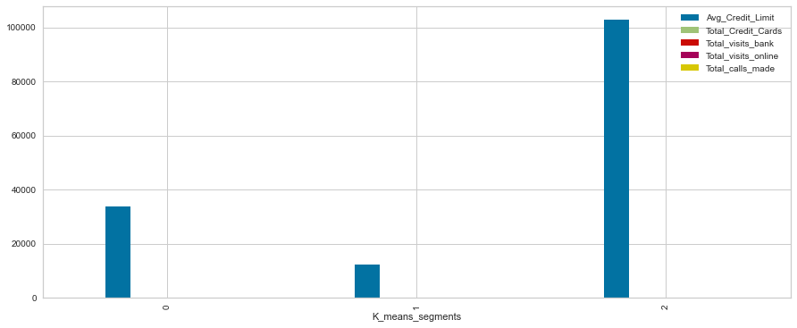

```python
customer_data.groupby("K_means_segments").mean().plot.bar(figsize=(15, 6))
```

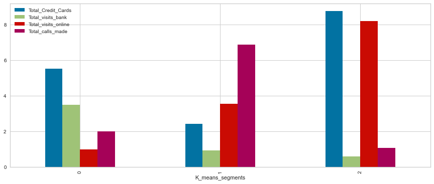

```python
customer_data_split.groupby("K_means_segments").mean().plot.bar(figsize=(15, 6))
```

### Hierarchical Clustering

```python
# list of distance metrics
distance_metrics = ["euclidean", "chebyshev", "mahalanobis", "cityblock"]

# list of linkage methods
linkage_methods = ["single", "complete", "average", "weighted"]

high_cophenet_corr = 0
high_dm_lm = [0, 0]

for dm in distance_metrics:
    for lm in linkage_methods:
        Z = linkage(customer_data_scaled_df, metric=dm, method=lm)
        c, coph_dists = cophenet(Z, pdist(customer_data_scaled_df))
        print(
            "Cophenetic correlation for {} distance and {} linkage is {}.".format(
                dm.capitalize(), lm, c
            )
        )
        if high_cophenet_corr < c:
            high_cophenet_corr = c
            high_dm_lm[0] = dm
            high_dm_lm[1] = lm
```

```
Cophenetic correlation for Euclidean distance and single linkage is 0.8245251847935283.
Cophenetic correlation for Euclidean distance and complete linkage is 0.835336246667918.
Cophenetic correlation for Euclidean distance and average linkage is 0.9135372845830776.
Cophenetic correlation for Euclidean distance and weighted linkage is 0.9086058561741279.
Cophenetic correlation for Chebyshev distance and single linkage is 0.8634644450642049.
Cophenetic correlation for Chebyshev distance and complete linkage is 0.7778629438523952.
Cophenetic correlation for Chebyshev distance and average linkage is 0.9107749000055766.
Cophenetic correlation for Chebyshev distance and weighted linkage is 0.8022608046966394.
Cophenetic correlation for Mahalanobis distance and single linkage is 0.8580748598585647.
Cophenetic correlation for Mahalanobis distance and complete linkage is 0.19790389062777564.
Cophenetic correlation for Mahalanobis distance and average linkage is 0.7961520068553004.
Cophenetic correlation for Mahalanobis distance and weighted linkage is 0.745462679144661.
Cophenetic correlation for Cityblock distance and single linkage is 0.7768085287837978.
Cophenetic correlation for Cityblock distance and complete linkage is 0.857205351797428.
Cophenetic correlation for Cityblock distance and average linkage is 0.9108573629783555.
Cophenetic correlation for Cityblock distance and weighted linkage is 0.8564893664431856.
```

```python
# printing the combination of distance metric and linkage method with the highest cophenetic correlation
print(
    "Highest cophenetic correlation is {}, which is obtained with {} distance and {} linkage.".format(
        high_cophenet_corr, high_dm_lm[0].capitalize(), high_dm_lm[1]
    )
)
```

```
Highest cophenetic correlation is 0.9135372845830776, which is obtained with Euclidean distance and average linkage.
```

### Let's explore different linkage methods with Euclidean distance only.

```python
# list of linkage methods
linkage_methods = ["single", "complete", "average", "centroid", "ward", "weighted"]

high_cophenet_corr = 0
high_dm_lm = [0, 0]

for lm in linkage_methods:
    Z = linkage(customer_data_scaled_df, metric="euclidean", method=lm)
    c, coph_dists = cophenet(Z, pdist(customer_data_scaled_df))
    print("Cophenetic correlation for {} linkage is {}.".format(lm, c))
    if high_cophenet_corr < c:
        high_cophenet_corr = c
        high_dm_lm[0] = "euclidean"
        high_dm_lm[1] = lm
```

```
Cophenetic correlation for single linkage is 0.8245251847935283.
Cophenetic correlation for complete linkage is 0.835336246667918.
Cophenetic correlation for average linkage is 0.9135372845830776.
Cophenetic correlation for centroid linkage is 0.9094142754907397.
Cophenetic correlation for ward linkage is 0.7966966681325903.
Cophenetic correlation for weighted linkage is 0.9086058561741279.
```

#### We see that the cophenetic correlation is maximum with Euclidean distance and average linkage.

#### Let's see the dendrograms for the different linkage methods.

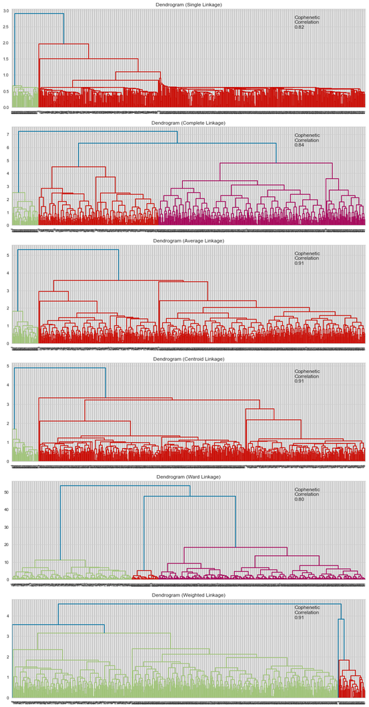

```python
# list of linkage methods
linkage_methods = ["single", "complete", "average", "centroid", "ward", "weighted"]

# lists to save results of cophenetic correlation calculation
compare_cols = ["Linkage", "Cophenetic Coefficient"]

# to create a subplot image
fig, axs = plt.subplots(len(linkage_methods), 1, figsize=(15, 30))

# We will enumerate through the list of linkage methods above
# For each linkage method, we will plot the dendrogram and calculate the cophenetic correlation
for i, method in enumerate(linkage_methods):
    Z = linkage(customer_data_scaled_df, metric="euclidean", method=method)

    dendrogram(Z, ax=axs[i])
    axs[i].set_title(f"Dendrogram ({method.capitalize()} Linkage)")

    coph_corr, coph_dist = cophenet(Z, pdist(customer_data_scaled_df))
    axs[i].annotate(
        f"Cophenetic\nCorrelation\n{coph_corr:0.2f}",
        (0.80, 0.80),
        xycoords="axes fraction",
    )
```

#### Observations:

- The cophenetic correlation is **highest** for average,centroid and weighted linkage methods of **Euclidean distance**.
- We will move ahead with **average linkage**.
- **3 appears to be the appropriate number of clusters** from the dendrogram for average linkage below which the height of the links tends to follow a decreasing pattern.

#### Lets check the silhouette score for Hierarchical clustering

[output not shown]

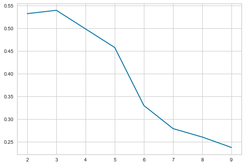

```python
sil_score_hc = []
cluster_list_hc = list(range(2, 10))
for n_clusters in cluster_list_hc:
    clusterer_hc = AgglomerativeClustering(n_clusters=n_clusters, affinity="euclidean", linkage="average" )
    preds_hc = clusterer_hc.fit_predict((customer_data_scaled_df))
    # centers = clusterer.cluster_centers_
    score_hc = silhouette_score(customer_data_scaled_df, preds_hc)
    sil_score_hc.append(score_hc)
    print("For n_clusters = {}, Hierarchical clustering silhouette score is {}".format(n_clusters, score_hc))

plt.plot(cluster_list_hc, sil_score_hc)
```

#### Observations:

- Upon checking the silhouette score for the Hierarchical clustering, the **score for 3 clusters is the highest at 0.539** cross-validating the dendogram, that 3 is the apt number of clusters for this dataset.

```python
HCmodel = AgglomerativeClustering(n_clusters=3, affinity="euclidean", linkage="average")
HCmodel.fit(customer_data_scaled_df)
```

```
AgglomerativeClustering(linkage='average', n_clusters=3)
```

```python
customer_data_scaled_df["HC_Clusters"] = HCmodel.labels_
customer_data["HC_Clusters"] = HCmodel.labels_
```

```python
customer_data.head(20)
```

|  | Avg_Credit_Limit | Total_Credit_Cards | Total_visits_bank | Total_visits_online | Total_calls_made | K_means_segments | HC_Clusters |
| --- | --- | --- | --- | --- | --- | --- | --- |
| 0 | 100000 | 2 | 1 | 1.0 | 0 | 0 | 0 |
| 1 | 50000 | 3 | 0 | 8.5 | 9 | 1 | 2 |
| 2 | 50000 | 7 | 1 | 3.0 | 4 | 0 | 0 |
| 3 | 30000 | 5 | 1 | 1.0 | 4 | 0 | 0 |
| 4 | 100000 | 6 | 0 | 8.5 | 3 | 2 | 1 |
| 5 | 20000 | 3 | 0 | 1.0 | 8 | 1 | 2 |
| 6 | 100000 | 5 | 0 | 8.5 | 2 | 2 | 1 |
| 7 | 15000 | 3 | 0 | 1.0 | 1 | 1 | 2 |
| 8 | 5000 | 2 | 0 | 2.0 | 2 | 1 | 2 |
| 9 | 3000 | 4 | 0 | 1.0 | 7 | 1 | 2 |
| 10 | 10000 | 4 | 0 | 5.0 | 5 | 1 | 2 |
| 11 | 13000 | 3 | 0 | 2.0 | 7 | 1 | 2 |
| 12 | 11000 | 1 | 2 | 5.0 | 9 | 1 | 2 |
| 13 | 9000 | 1 | 1 | 5.0 | 6 | 1 | 2 |
| 14 | 6000 | 2 | 2 | 4.0 | 6 | 1 | 2 |
| 15 | 8000 | 2 | 0 | 5.0 | 7 | 1 | 2 |
| 16 | 15000 | 2 | 1 | 2.0 | 4 | 1 | 2 |
| 17 | 8000 | 2 | 0 | 3.0 | 4 | 1 | 2 |
| 18 | 11000 | 2 | 2 | 2.0 | 7 | 1 | 2 |
| 19 | 19000 | 4 | 1 | 5.0 | 8 | 1 | 2 |

### Hierarchical Cluster Profiling

```python
cluster_profile_hc = customer_data.groupby("HC_Clusters").mean()
```

```python
cluster_profile_hc["count_in_each_segments"] = (
    customer_data.groupby("HC_Clusters")["Total_Credit_Cards"].count().values
)
```

```python
# lets display cluster profile
cluster_profile_hc.style.highlight_max(color="lightgreen", axis=0)
```

| HC_Clusters | Avg_Credit_Limit | Total_Credit_Cards | Total_visits_bank | Total_visits_online | Total_calls_made | K_means_segments | count_in_each_segments |
| --- | --- | --- | --- | --- | --- | --- | --- |
| 0 | 33782.383420 | 5.515544 | 3.489637 | 0.981865 | 2.000000 | 0 | 386 |
| 1 | 102660.000000 | 8.740000 | 0.600000 | 8.180000 | 1.080000 | 2 | 50 |
| 2 | 12174.107143 | 2.410714 | 0.933036 | 3.546875 | 6.870536 | 1 | 224 |

### Boxplot and barplot visualization of Hierarchical Clusters

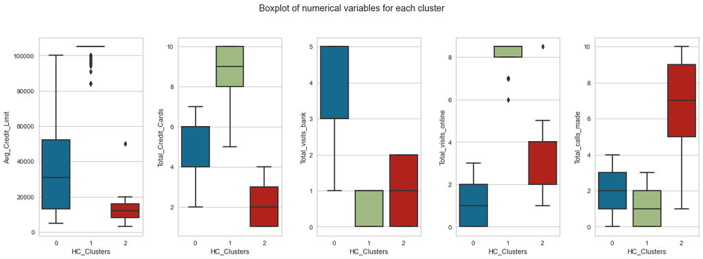

```python
fig, axes = plt.subplots(1, 5, figsize=(16, 6))
fig.suptitle("Boxplot of numerical variables for each cluster")
counter = 0
for ii in range(5):
    sns.boxplot(ax=axes[ii], y=customer_data[numerical_col[counter]], x=customer_data["HC_Clusters"])
    counter = counter + 1

fig.tight_layout(pad=2.0)
```

#### Observations:

##### Cluster 1:

- The average credit limit is below 110k.This seems to be the group capturing all the outliers.
- More than 25% of customers in this category have around 8-10 credit cards and the minimum here is 5 maximum is around 10.
- Customers in this cluster group do a minimum number of bank visits 0 or 1.They are mostly online customers.
- Customers in this group have maximum online usage.Most customers has a minimum of 8 online visits to 9 online being the maximum.
- Customers in this cluster group has made least number of calls to the bank on average with a 25% making no calls and maximum of 3 calls.

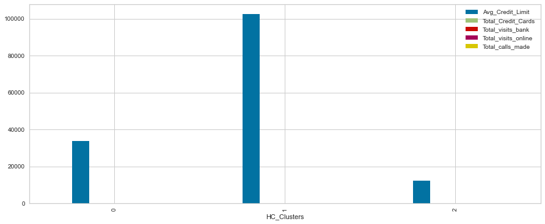

```python
customer_data_hc = customer_data.copy()
customer_data_hc.drop('K_means_segments',axis = 1, inplace=True)
customer_data_hc.groupby("HC_Clusters").mean().plot.bar(figsize=(15, 6))
```

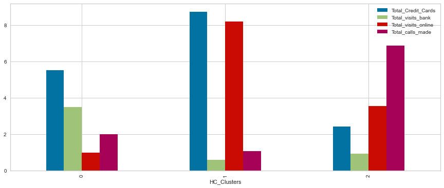

```python
customer_data_split_hc = customer_data_hc.copy()
customer_data_split_hc.drop('Avg_Credit_Limit',axis=1, inplace=True)
customer_data_split_hc.groupby("HC_Clusters").mean().plot.bar(figsize=(15, 6))
```

### Conclusion and Recommendations:

- Both KMeans and Hierarchical clustering has given us the same results.
- KMeans and Hierarchical cluster groups 1 and 2 has cluster labels swapped with same grouping.Data in all the three clusters across both methods are identical.
- Cluster 1 in KMeans and Cluster 2 in Hierarchical are the target group for Business to upsell their credit cards and to inprove their customer/delivery services to make their customers happy.
- Cluster 2 in KMeans and Cluster 1 in Hierarchical clustering have captured all the high end outliers.Online marketing strategies and online services can be targetted/focussed for this group.Premium Services can also be targetted.
- Cluster 0 has more traditional /conservative customers and in person banking services with attractive flyers on the bank promotions and friendly personal banker services can be the areas of focus for this group.